# Reproducible Research: Peer Assessment 1

Achintya Sen

### This assignment makes use of data from a personal activity monitoring device. This device collects data at 5 minute intervals through out the day. The data consists of two months of data from an anonymous individual collected during the months of October and November, 2012 and include the number of steps taken in 5 minute intervals each day.

## 1. Loading and preprocessing the data

##### Import the data using the read.csv function into the R environment.

```r
activity_data <-  read.csv("activity.csv")
head(activity_data)
```

```
##   steps       date interval
## 1    NA 2012-10-01        0
## 2    NA 2012-10-01        5
## 3    NA 2012-10-01       10
## 4    NA 2012-10-01       15
## 5    NA 2012-10-01       20
## 6    NA 2012-10-01       25
```

```r
str(activity_data)
```

```
## 'data.frame':    17568 obs. of  3 variables:
##  $ steps   : int  NA NA NA NA NA NA NA NA NA NA ...
##  $ date    : Factor w/ 61 levels "2012-10-01","2012-10-02",..: 1 1 1 1 1 1 1 1 1 1 ...
##  $ interval: int  0 5 10 15 20 25 30 35 40 45 ...
```

### For this part of the assignment, you can ignore the missing values in the dataset.

### a) Calculate the total number of steps taken per day

```r
steps_per_day <- aggregate(steps~date,data = activity_data,sum,na.rm=TRUE)
```

### b) If you do not understand the difference between a histogram and a barplot, research the difference between them. Make a histogram of the total number of steps taken each day.

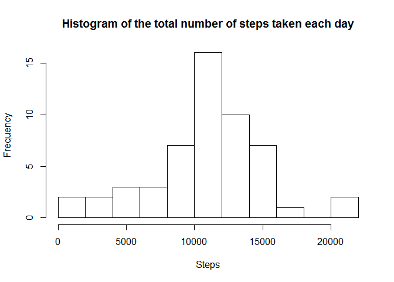

```r
hist(steps_per_day$steps,main = "Histogram of the total number of steps taken each day",xlab = "Steps",breaks = 15)
```

```r
library(dplyr)
mean_median_steps_per_day <- group_by(activity_data, date) %>%
    summarise(mean = mean(steps, na.rm = TRUE),
              median = median(steps, na.rm = TRUE))
head(mean_median_steps_per_day)
```

```
## # A tibble: 6 × 3
##         date     mean median
##       <fctr>    <dbl>  <dbl>
## 1 2012-10-01      NaN     NA
## 2 2012-10-02  0.43750      0
## 3 2012-10-03 39.41667      0
## 4 2012-10-04 42.06944      0
## 5 2012-10-05 46.15972      0
## 6 2012-10-06 53.54167      0
```

## 3. What is the average daily activity pattern?

### a) Make a time series plot (i.e. type = “l”) of the 5-minute interval (x-axis) and the average number of steps taken, averaged across all days (y-axis)

```r
interval <- activity_data %>%
  filter(!is.na(steps)) %>%
  group_by(interval) %>%
  summarize(steps = mean(steps))
```

Ploting the graph through the base plotting system.

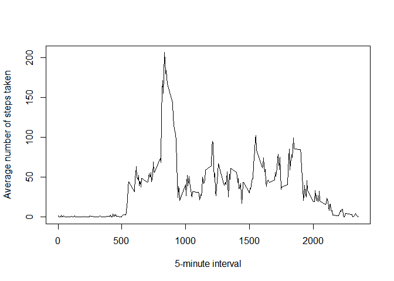

```r
plot(steps~interval,data= interval,type="l", xlab="5-minute interval",ylab = "Average number of steps taken")
```

### b) Which 5-minute interval, on average across all the days in the dataset, contains the maximum number of steps?

```r
interval[which.max(interval$steps),]
```

```
## # A tibble: 1 × 2
##   interval    steps
##      <int>    <dbl>
## 1      835 206.1698
```